# Does music really fit into genres?

By Hannah Darrow and Miranda Song

# Introduction

Musical genres are an important aspect of classifying music. We searched for music-related databases on Kaggle and found several related to genre classification. Our selected dataset contains numerical data and categorizes each song by genre. We chose this dataset so we could use the numerical data to predict genre. Most other music datasets did not include genre labels. In the original dataset "data.csv," there existed ten unique labels - blues, classical, country, disco, hiphop, jazz, metal, pop, reggae, and rock. We decided to choose five of the ten labels to decrease the number of classes on which to train the algorithms, and specifically, we chose the five labels classical, country, disco, pop, and jazz because we made a qualitative prediction that these music genres were the most distinct out of the ten provided by the original dataset. We chose the tempo, chroma_stft, rolloff, and zero crossing rate as potential independent variables to predict the tempo of a song because these metrics have relevance to the content of the song itself, and so we projected that they could be important indicators to predicting the correct genre of the song. Specifically, the tempo of the song is the speed at which a passage of music is or should be played, the chroma stft is a short-term Fourier transformation to compute Chroma features and represents information about the classification of pitch and signal structure, the rolloff in a song is the smooth fall of response to zero at either end of the frequency range of a piece of audio equipment, and the zero crossing rate of the song is the rate at which a signal changes from positive to zero to negative or from negative to zero to positive. Thus, with these descriptions, it is apparent that these columns are relevant to the construction of the song and thus could potentially help predict the genre of the song.

```python
import spotipy
import pandas as pd
sp = spotipy.Spotify()
from spotipy.oauth2 import SpotifyClientCredentials
import spotipy.util as util
import os
import numpy as np
import matplotlib.pyplot as plt
import librosa.display
import seaborn as sns
```

Referencing the data collection process from the Kaggle dataset, we pulled information about the audio features of our top 100 favorite songs over the past year. Consistent with our selected Kaggle dataset, we analyzed only 30 seconds of each song. We obtained only the features we previously selected for our algorithms to save some computing time.

```python
top_songs = pd.DataFrame(columns=['tempo', 'chroma_stft', 'rolloff', 'zero_crossing_rate', 'label', 'title'])
for filename in os.listdir('./top_100/'):
    song = f'./top_100/{filename}'
    data, sampling_rate = librosa.load(song, mono=True, duration=30)
    tempo, beats = librosa.beat.beat_track(y=data, sr=sampling_rate)
    chroma_stft = librosa.feature.chroma_stft(y=data, sr=sampling_rate)
    rolloff = librosa.feature.spectral_rolloff(y=data, sr=sampling_rate)
    zero_crossing_rate = librosa.feature.zero_crossing_rate(data)
    top_songs.loc[len(top_songs.index)] = [tempo, np.mean(chroma_stft), np.mean(rolloff), np.mean(zero_crossing_rate), filename, f'{filename}'.replace(".wav", "")]
```

Since genre is not obtainable through the librosa package, we used the spotipy package to obtain the artist genres for each artist in our playlist. Spotify does not provide genre information for individual songs, but the artist's genre is a good estimator of the genre of the song. We then combined the genres with the data gathered using librosa.

```python
os.environ['SPOTIPY_CLIENT_ID'] = "5460cbf36b244e6fa5fcbe8cd53fb054"
os.environ['SPOTIPY_CLIENT_SECRET'] = "207be6b72936460b81dab93919fef308"
sp = spotipy.Spotify(client_credentials_manager=SpotifyClientCredentials())
link = 'https://open.spotify.com/playlist/5tWU3ryoUrBvYOIFwYr76Q?si=61bfad1af9ea4cee'
playlist_URI = link.split("/")[-1].split("?")[0]
track_uris = [x["track"]["uri"] for x in sp.playlist_tracks(playlist_URI)["items"]]

spotify = pd.DataFrame(columns=['label', 'title'])

for track in sp.playlist_tracks(playlist_URI)["items"]:
    #Main Artist
    artist_uri = track["track"]["artists"][0]["uri"]
    artist_info = sp.artist(artist_uri)
    artist_genres = artist_info["genres"]
    spotify.loc[len(spotify.index)] = [artist_genres, track["track"]["name"]]
```

In order to classify each song in one of our five genre categories, we had to simplify some of their genre descriptors. We classified each artist based on the words contained in the genre arrays provided by Spotify. We chose to count soundtrack as classical music because our soundtrack songs came from Pride and Prejudice and Little Women, two films with classical-style instrumental soundtracks. Our dataset contained several indie artists, so we decided to classify them as pop artists. We found that our dataset contained classical, country, and pop music, with the majority of the songs being classified as pop.

```python
for index, row in spotify.iterrows():
    string = ' '.join([str(elem) for elem in row['label']])
    if 'soundtrack' in string:
        row['label'] = 'classical'
    elif 'country' in string:
        row['label'] = 'country'
    elif 'disco' in string:
        row['label'] = 'disco'
    elif 'jazz' in string:
        row['label'] = 'jazz'
    elif 'pop' or 'indie' in string:
        row['label'] = 'pop'
```

```python
spotify = spotify.sort_values('title')
```

```python
top_songs = top_songs.sort_values('label')
```

```python
top_songs['label'] = spotify['label']
```

```python
top_songs.to_csv('top_songs.csv')
```

```python
top_songs.sort_values('zero_crossing_rate')
```

|  | tempo | chroma_stft | rolloff | zero_crossing_rate | label | title |
| --- | --- | --- | --- | --- | --- | --- |
| 29 | 99.384014 | 0.436686 | 2371.568993 | 0.017494 | pop | Give Me a Kiss |
| 17 | 129.199219 | 0.297507 | 1141.359765 | 0.022631 | pop | called you again |
| 86 | 129.199219 | 0.346383 | 984.227382 | 0.025018 | pop | The First Disciple |
| 60 | 123.046875 | 0.434861 | 1936.029960 | 0.026176 | pop | nothing else i could do |
| 13 | 89.102909 | 0.327201 | 1208.226027 | 0.028171 | pop | Break The Rhythm |
| ... | ... | ... | ... | ... | ... | ... |
| 7 | 129.199219 | 0.405386 | 5058.452746 | 0.109667 | pop | Before I Do |
| 76 | 123.046875 | 0.335675 | 4853.262320 | 0.118170 | pop | Slow Down |
| 69 | 135.999178 | 0.276024 | 4045.267205 | 0.124563 | pop | Punching Bag |
| 44 | 86.132812 | 0.458806 | 5456.150341 | 0.125496 | pop | Intimacy |
| 90 | 129.199219 | 0.453164 | 6212.229102 | 0.151419 | pop | Tongue Tied |

100 rows × 6 columns

# Data Visualization

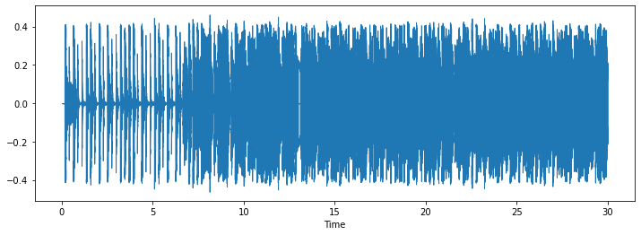

```python
data, sampling_rate = librosa.load('./top_100/Tongue Tied.wav', mono=True, duration=30)
plt.figure(figsize=(12, 4))
librosa.display.waveshow(data, sr=sampling_rate)
plt.show()
```

This is a graph of the waveform of the song with the highest zero crossing rate over time. Zero crossing rate indicates the rate at which the audio crosses the horizontal axis, and this graph clearly displays a high zero crossing rate, especially at the beginning of the song. The graph frequently approaches the horizontal axis.

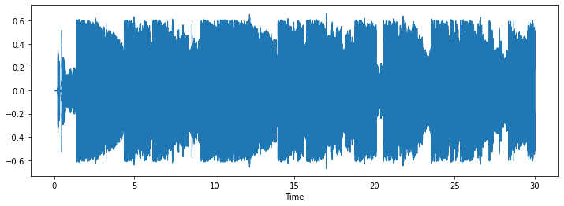

```python
data, sampling_rate = librosa.load('./top_100/Give Me a Kiss.wav', mono=True, duration=30)
plt.figure(figsize=(12, 4))
librosa.display.waveshow(data, sr=sampling_rate)
plt.show()
```

The above graph shows the waveform of the song with the lowest zero crossing rate. When compared to the first waveform graph, this song has fewer values close to the horizontal axis. Instead, most of the values fluctuate between +- 0.2 and +- 0.6. This is consistent with the definition of zero-crossing rate.

```python
music_data = pd.read_csv('data.csv')
music_data = music_data[(music_data['label'] == 'classical') | (music_data['label'] == 'country') | (music_data['label'] == 'disco') \
    | (music_data['label'] == 'pop') | (music_data['label'] == 'jazz')]
music_data = music_data[['tempo', 'chroma_stft', 'rolloff', 'zero_crossing_rate', 'label']]
```

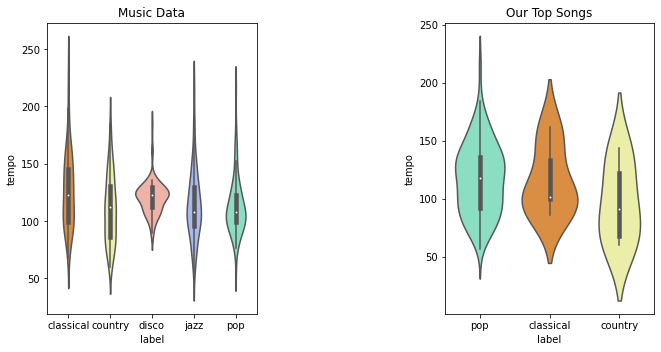

```python
fig = plt.figure()
colors = {'classical': "#F28E2B", 'country': "#F5F99E", 'pop': "#7DECC5", 'disco': "#F9AA9E", 'jazz': "#9EB4F9"}
fig.subplots_adjust(hspace=0.8, wspace=0.9)
ax = fig.add_subplot(2,3,1)
fig.set_size_inches(18, 15)
sns.violinplot(x='label', y='tempo', data=music_data, palette=colors)
plt.title("Music Data")
ax = fig.add_subplot(2,3,2)
fig.set_size_inches(18, 15)
sns.violinplot(x='label', y='tempo', data=top_songs, palette=colors)
plt.title("Our Top Songs")
plt.show()
```

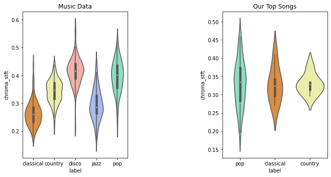

```python
fig = plt.figure()
fig.subplots_adjust(hspace=0.8, wspace=0.9)
ax = fig.add_subplot(2,3,1)
fig.set_size_inches(18, 15)
sns.violinplot(x='label', y='chroma_stft', data=music_data, palette=colors)
plt.title("Music Data")
ax = fig.add_subplot(2,3,2)
fig.set_size_inches(18, 15)
sns.violinplot(x='label', y='chroma_stft', data=top_songs, palette=colors)
plt.title("Our Top Songs")
plt.show()
```

In the above graph, chroma short-term Fourier transformation is grouped by genre. Within our top songs, country has the highest mean value and classical has the lowest mean value by a small margin. In the Kaggle dataset, classical also has the lowest mean value, and disco has the highest mean value.

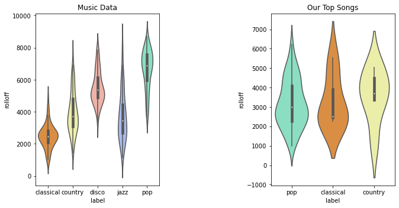

```python
fig = plt.figure()
fig.subplots_adjust(hspace=0.8, wspace=0.9)
ax = fig.add_subplot(2,3,1)
fig.set_size_inches(18, 15)
sns.violinplot(x='label', y='rolloff', data=music_data, palette=colors)
plt.title("Music Data")
ax = fig.add_subplot(2,3,2)
fig.set_size_inches(18, 15)
sns.violinplot(x='label', y='rolloff', data=top_songs, palette=colors)
plt.title("Our Top Songs")
plt.show()
```

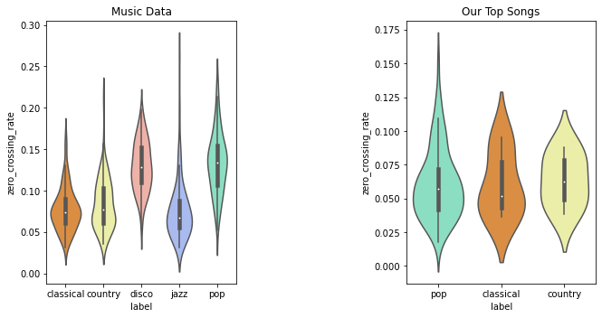

```python
fig = plt.figure()
fig.subplots_adjust(hspace=0.8, wspace=0.9)
ax = fig.add_subplot(2,3,1)
fig.set_size_inches(18, 15)
sns.violinplot(x='label', y='zero_crossing_rate', data=music_data, palette=colors)
plt.title("Music Data")
ax = fig.add_subplot(2,3,2)
fig.set_size_inches(18, 15)
sns.violinplot(x='label', y='zero_crossing_rate', data=top_songs, palette=colors)
plt.title("Our Top Songs")
plt.show()
```

```python
from sklearn.model_selection import train_test_split
from sklearn.model_selection import GridSearchCV
from sklearn.neighbors import KNeighborsClassifier
from sklearn.metrics import confusion_matrix, accuracy_score
from sklearn.metrics import classification_report

data = pd.read_csv("data.csv")
print(data["label"].unique())
```

```
['blues' 'classical' 'country' 'disco' 'hiphop' 'jazz' 'metal' 'pop'
 'reggae' 'rock']
```

```python
df = pd.DataFrame(data[(data["label"] == "classical") | (data["label"] == "country") | (data["label"] == "disco") | (data["label"] == "pop") | (data["label"] == "jazz")])
df = df[['label', 'tempo', 'chroma_stft', 'rolloff', 'zero_crossing_rate']]
df
```

|  | label | tempo | chroma_stft | rolloff | zero_crossing_rate |
| --- | --- | --- | --- | --- | --- |
| 100 | classical | 92.285156 | 0.223738 | 4066.467077 | 0.152438 |
| 101 | classical | 161.499023 | 0.284173 | 2838.224504 | 0.093952 |
| 102 | classical | 143.554688 | 0.208113 | 2615.059187 | 0.075857 |
| 103 | classical | 95.703125 | 0.312900 | 3077.806389 | 0.096726 |
| 104 | classical | 123.046875 | 0.258572 | 2082.504074 | 0.066325 |
| ... | ... | ... | ... | ... | ... |
| 795 | pop | 129.199219 | 0.292246 | 3821.218560 | 0.095811 |
| 796 | pop | 151.999081 | 0.333196 | 6101.779770 | 0.128548 |
| 797 | pop | 117.453835 | 0.425849 | 4139.074972 | 0.088061 |
| 798 | pop | 80.749512 | 0.316734 | 3796.293711 | 0.074647 |
| 799 | pop | 99.384014 | 0.349357 | 6655.701421 | 0.121270 |

500 rows × 5 columns

```python
X = df.iloc[:, [1,2,3,4]].values
y = df.iloc[:, 0].values
```

# Predicting Song Genre: K-Nearest Neighbor and Decision Tree Algorithms

```python
print('X - [tempo, chroma_stft, rolloff, zero_crossing_rate]:', X[0])
print('y - label:', y[0])
```

```
X - [tempo, chroma_stft, rolloff, zero_crossing_rate]: [9.22851562e+01 2.23738306e-01 4.06646708e+03 1.52437854e-01]
y - label: classical
```

```python
X_train, X_test, y_train, y_test = train_test_split(X, y, test_size = 0.10, random_state = 0)
param_grid = {'n_neighbors': [1, 2, 3, 4, 5, 6, 7, 8, 9, 10, 11, 12, 13],
              'metric': ['minkowski'],
              'p': [2]}

grid = GridSearchCV(KNeighborsClassifier(), param_grid, refit = True, verbose = 3,n_jobs=-1)

grid.fit(X_train, y_train)
print(grid.best_params_)
pred = grid.predict(X_test)
print(classification_report(y_test, pred))
```

```
Fitting 5 folds for each of 13 candidates, totalling 65 fits
{'metric': 'minkowski', 'n_neighbors': 10, 'p': 2}
              precision    recall  f1-score   support

   classical       0.69      1.00      0.82         9
     country       0.75      0.67      0.71         9
       disco       0.73      0.73      0.73        11
        jazz       1.00      0.27      0.43        11
         pop       0.67      1.00      0.80        10

    accuracy                           0.72        50
   macro avg       0.77      0.73      0.70        50
weighted avg       0.77      0.72      0.69        50
```

From here, we can see that the accuracy of the k-nearest neighbor algorithm is around 0.72 or 72 percent with the hyperparameter selected as 10 nearest neighbors to classify the song at hand. More specifically and interestingly, the individual genres are predicted at different precision and recall rates. The highest rate of precision, a measure of how well the results are close to one another in the dataset, occurs in jazz. This may indicate that the jazz songs in the dataset tend to have similar metrics that we are training on, such as the tempo or zero crossing rate, and thus jazz songs could be seen as more highly clustered together than the other genres and have a higher precision rate. On the other hand, the highest rates of recall occur in the classical and pop genres, which indicates that these genres have the most relevant songs that have been classified.

```python
from sklearn.tree import DecisionTreeClassifier

x = np.array(df[["tempo", "chroma_stft", "rolloff", "zero_crossing_rate"]])
y = np.array(df[["label"]])
xtrain, xtest, ytrain, ytest = train_test_split(x, y, test_size=0.10, random_state=42)
model = DecisionTreeClassifier()
model.fit(xtrain, ytrain)
predictions = model.predict(xtest)
print(classification_report(ytest, predictions))
```

```
              precision    recall  f1-score   support

   classical       0.92      0.73      0.81        15
     country       0.50      0.29      0.36         7
       disco       0.30      1.00      0.46         3
        jazz       0.50      0.58      0.54        12
         pop       0.70      0.54      0.61        13

    accuracy                           0.60        50
   macro avg       0.58      0.63      0.56        50
weighted avg       0.67      0.60      0.61        50
```

We also used the decision tree classification algorithm to determine the genre/label of the songs, and we found that the accuracy of this algorithm was lower than the k-nearest neighbor model with an accuracy of around 0.60 or 60 percent as compared to the KNN algorithm's 0.72 or 72 percent accuracy. Interestingly, the highest precision rate occur in the classical genre instead of jazz in this model, and we see that the highest recall rate occurs in disco. Since a small change in the data can result in a major change in the structure of the decision tree, we can see that it may perform worse than a KNN algorithm since it is more sensitive when completing classifications.

# Linear Regression Testing and Analysis

Here, instead of predicting the genre of the song, we are looking to predict the tempo of the song based on genre and other variables (columns) in the dataset using linear regression. We explore four major relationships below.

```python
import statsmodels.api as sm
import statsmodels.formula.api as smf

regression = smf.ols(formula='tempo ~ C(label)', data=df).fit()
print(regression.summary())
```

```
                            OLS Regression Results
==============================================================================
Dep. Variable:                  tempo   R-squared:                       0.044
Model:                            OLS   Adj. R-squared:                  0.036
Method:                 Least Squares   F-statistic:                     5.716
Date:                Fri, 16 Dec 2022   Prob (F-statistic):           0.000167
Time:                        21:37:10   Log-Likelihood:                -2361.3
No. Observations:                 500   AIC:                             4733.
Df Residuals:                     495   BIC:                             4754.
Df Model:                           4
Covariance Type:            nonrobust
=======================================================================================
                          coef    std err          t      P>|t|      [0.025      0.975]
---------------------------------------------------------------------------------------
Intercept             127.0323      2.735     46.448      0.000     121.659     132.406
C(label)[T.country]   -16.1734      3.868     -4.182      0.000     -23.773      -8.574
C(label)[T.disco]      -6.6905      3.868     -1.730      0.084     -14.290       0.909
C(label)[T.jazz]      -11.9641      3.868     -3.093      0.002     -19.563      -4.365
C(label)[T.pop]       -14.2723      3.868     -3.690      0.000     -21.872      -6.673
==============================================================================
Omnibus:                       61.952   Durbin-Watson:                   2.088
Prob(Omnibus):                  0.000   Jarque-Bera (JB):               95.466
Skew:                           0.814   Prob(JB):                     1.86e-21
Kurtosis:                       4.391   Cond. No.                         5.83
==============================================================================

Notes:
[1] Standard Errors assume that the covariance matrix of the errors is correctly specified.
```

First, we decided to perform the linear regression analysis between the tempo of the song and the genre of the song. We can see from the OLS regression output that the intercept itself is the classical genre, and comparatively, all other genres including country, disco, jazz, and pop, have slower tempos than the classical genre. We find this interesting and logical, as although the classical music genre tends to be known for a slower pace, it does have variation in its pieces/songs, and so this regression result indicates to us that this dataset likely has classical songs that are more fast-paced than its counterparts in other categories.

```python
regression = smf.ols(formula='tempo ~ C(label) + chroma_stft', data=df).fit()
print(regression.summary())
```

```
                            OLS Regression Results
==============================================================================
Dep. Variable:                  tempo   R-squared:                       0.049
Model:                            OLS   Adj. R-squared:                  0.039
Method:                 Least Squares   F-statistic:                     5.038
Date:                Fri, 16 Dec 2022   Prob (F-statistic):           0.000163
Time:                        21:37:10   Log-Likelihood:                -2360.2
No. Observations:                 500   AIC:                             4732.
Df Residuals:                     494   BIC:                             4758.
Df Model:                           5
Covariance Type:            nonrobust
=======================================================================================
                          coef    std err          t      P>|t|      [0.025      0.975]
---------------------------------------------------------------------------------------
Intercept             117.1068      7.135     16.412      0.000     103.087     131.126
C(label)[T.country]   -19.1956      4.353     -4.410      0.000     -27.749     -10.643
C(label)[T.disco]     -12.4205      5.423     -2.291      0.022     -23.074      -1.766
C(label)[T.jazz]      -13.2102      3.950     -3.344      0.001     -20.972      -5.448
C(label)[T.pop]       -19.3176      5.114     -3.778      0.000     -29.365      -9.270
chroma_stft            37.6627     25.014      1.506      0.133     -11.484      86.809
==============================================================================
Omnibus:                       66.700   Durbin-Watson:                   2.096
Prob(Omnibus):                  0.000   Jarque-Bera (JB):              103.236
Skew:                           0.865   Prob(JB):                     3.82e-23
Kurtosis:                       4.401   Cond. No.                         24.6
==============================================================================

Notes:
[1] Standard Errors assume that the covariance matrix of the errors is correctly specified.
```

With the knowledge that the genre of the song is already a variable in predicting the tempo of the song, we can explore the relationship of another variable with tempo - chroma_stft. We previously defined how chroma_stft is a metric of the content of a song, and now we can see that these two variables definitely shift the prediction of the tempo from the previously observed relationship between only genre and tempo.

The new ordering of the genre of the songs regarding tempo has been altered - it is now 1) classical, 2) disco, 3) jazz, 4) country, and 5) pop. It is interesting to see that the addition of the chroma_stft variable has switched the pop and country genres (even though it is a very close difference of 117.1068 - 19.1956 = 97.9112 and 117.1068 - 19.3176 = 97.7892 between ordering the two genres).

```python
regression = smf.ols(formula='tempo ~ C(label) + rolloff', data=df).fit()
print(regression.summary())
```

```
                            OLS Regression Results
==============================================================================
Dep. Variable:                  tempo   R-squared:                       0.048
Model:                            OLS   Adj. R-squared:                  0.038
Method:                 Least Squares   F-statistic:                     4.946
Date:                Fri, 16 Dec 2022   Prob (F-statistic):           0.000198
Time:                        21:37:10   Log-Likelihood:                -2360.4
No. Observations:                 500   AIC:                             4733.
Df Residuals:                     494   BIC:                             4758.
Df Model:                           5
Covariance Type:            nonrobust
=======================================================================================
                          coef    std err          t      P>|t|      [0.025      0.975]
---------------------------------------------------------------------------------------
Intercept             123.6056      3.727     33.163      0.000     116.283     130.929
C(label)[T.country]   -18.1980      4.145     -4.391      0.000     -26.341     -10.055
C(label)[T.disco]     -10.8833      4.955     -2.196      0.029     -20.619      -1.148
C(label)[T.jazz]      -13.7142      4.076     -3.365      0.001     -21.722      -5.707
C(label)[T.pop]       -20.0318      5.752     -3.483      0.001     -31.333      -8.731
rolloff                 0.0014      0.001      1.352      0.177      -0.001       0.003
==============================================================================
Omnibus:                       63.925   Durbin-Watson:                   2.104
Prob(Omnibus):                  0.000   Jarque-Bera (JB):               98.189
Skew:                           0.838   Prob(JB):                     4.77e-22
Kurtosis:                       4.381   Cond. No.                     3.23e+04
==============================================================================

Notes:
[1] Standard Errors assume that the covariance matrix of the errors is correctly specified.
[2] The condition number is large, 3.23e+04. This might indicate that there are
strong multicollinearity or other numerical problems.
```

```python
regression = smf.ols(formula='tempo ~ C(label) + zero_crossing_rate', data=df).fit()
print(regression.summary())
```

```
                            OLS Regression Results
==============================================================================
Dep. Variable:                  tempo   R-squared:                       0.046
Model:                            OLS   Adj. R-squared:                  0.036
Method:                 Least Squares   F-statistic:                     4.761
Date:                Fri, 16 Dec 2022   Prob (F-statistic):           0.000293
Time:                        21:37:10   Log-Likelihood:                -2360.8
No. Observations:                 500   AIC:                             4734.
Df Residuals:                     494   BIC:                             4759.
Df Model:                           5
Covariance Type:            nonrobust
=======================================================================================
                          coef    std err          t      P>|t|      [0.025      0.975]
---------------------------------------------------------------------------------------
Intercept             124.1649      4.023     30.860      0.000     116.260     132.070
C(label)[T.country]   -16.3866      3.874     -4.230      0.000     -23.998      -8.775
C(label)[T.disco]      -8.6025      4.340     -1.982      0.048     -17.129      -0.076
C(label)[T.jazz]      -11.9399      3.868     -3.087      0.002     -19.540      -4.340
C(label)[T.pop]       -16.3397      4.414     -3.701      0.000     -25.013      -7.666
zero_crossing_rate     36.9342     38.009      0.972      0.332     -37.746     111.614
==============================================================================
Omnibus:                       63.768   Durbin-Watson:                   2.096
Prob(Omnibus):                  0.000   Jarque-Bera (JB):               98.513
Skew:                           0.833   Prob(JB):                     4.06e-22
Kurtosis:                       4.398   Cond. No.                         33.9
==============================================================================

Notes:
[1] Standard Errors assume that the covariance matrix of the errors is correctly specified.
```

Lastly, we will take a look at how the zero crossing rate in conjunction with genre can help predict the tempo of the song. It looks like classical is the clear winner yet again! Here is our updated ranking as compared to the baseline ranking - 1) classical, 2) disco, 3) jazz, 4) pop, and 5) country. It seems like zero crossing rate has less of an influence than the previous two variables chroma_stft and rolloff, as the ranking of the genres has not changed relative to our baseline when only genre is predicting the tempo.

# Predicting Song Genre: Our Top 100 Songs

Now it is time to apply the analytical process of the KNN and decision tree algorithms to our own dataset - our top 100 favorite songs listened to on Spotify in the last year.

```python
top100df = pd.read_csv("top_songs.csv")
top100df = top100df[['label', 'tempo', 'chroma_stft', 'rolloff', 'zero_crossing_rate']]
top100df
```

|  | label | tempo | chroma_stft | rolloff | zero_crossing_rate |
| --- | --- | --- | --- | --- | --- |
| 0 | pop | 73.828125 | 0.419601 | 2186.553445 | 0.031743 |
| 1 | pop | 143.554688 | 0.341414 | 2956.365457 | 0.058510 |
| 2 | pop | 161.499023 | 0.385302 | 4645.163578 | 0.099463 |
| 3 | pop | 75.999540 | 0.339110 | 5390.542404 | 0.099794 |
| 4 | pop | 107.666016 | 0.294545 | 3635.344684 | 0.108542 |
| ... | ... | ... | ... | ... | ... |
| 95 | pop | 143.554688 | 0.356825 | 4073.367036 | 0.049890 |
| 96 | pop | 123.046875 | 0.434861 | 1936.029960 | 0.026176 |
| 97 | classical | 99.384014 | 0.407459 | 4377.140199 | 0.085504 |
| 98 | pop | 143.554688 | 0.241262 | 4221.432807 | 0.064830 |
| 99 | pop | 83.354335 | 0.257877 | 4151.683229 | 0.081161 |

100 rows × 5 columns

```python
X = top100df.iloc[:, [1,2,3,4]].values
y = top100df.iloc[:, 0].values
print('X - [tempo, chroma_stft, rolloff, zero_crossing_rate]:', X[0])
print('y - label:', y[0])
```

```
X - [tempo, chroma_stft, rolloff, zero_crossing_rate]: [7.38281250e+01 4.19600640e-01 2.18655344e+03 3.17428164e-02]
y - label: pop
```

```python
X_train, X_test, y_train, y_test = train_test_split(X, y, test_size = 0.10, random_state = 0)
param_grid = {'n_neighbors': [1, 2, 3, 4, 5, 6, 7, 8, 9, 10, 11, 12, 13],
              'metric': ['minkowski'],
              'p': [2]}

grid = GridSearchCV(KNeighborsClassifier(), param_grid, refit = True, verbose = 3,n_jobs=-1)

grid.fit(X_train, y_train)
print(grid.best_params_)
pred = grid.predict(X_test)
print(classification_report(y_test, pred))
```

```
Fitting 5 folds for each of 13 candidates, totalling 65 fits
{'metric': 'minkowski', 'n_neighbors': 5, 'p': 2}
              precision    recall  f1-score   support

   classical       0.00      0.00      0.00         2
     country       0.00      0.00      0.00         1
         pop       0.70      1.00      0.82         7

    accuracy                           0.70        10
   macro avg       0.23      0.33      0.27        10
weighted avg       0.49      0.70      0.58        10
```

We can see that the accuracy of the k-nearest neighbor algorithm is around 0.70 or 70 percent with the hyperparameter selected as 5 nearest neighbors to classify the song at hand. We have fewer genres in the classification for this dataset, as our dataset diversity of genres for both the training and test sets is lower. The highest rate of precision and recall both occur in the pop genre, as the dataset is highly skewed towards the pop genre in terms of the total number of songs included.

# Further Analysis and Conclusion

Music is hardly fit for black-and-white classification for genre. However, we decided to take the challenge and explore if there really did exist any relationships between how the rolloff of a song could predict its tempo in conjunction with its genre, or whether the combination of the genre and zero crossing rate of a song could predict the beats per minute of a song. Of course, there exist many more genres than the five we decided to explore in this dataset. In fact, as aforementioned, the dataset itself had ten genres, including the five genres we didn't explore - blues, hiphop, metal, reggae, and rock. The introduction of more genres increases the difficulty of the classification problem - what factor(s) exactly influence or define the genre of a song? What can we say about the similarities in genre, and who is to say that one song cannot be in two or more genres at once? With these questions in mind, we may ponder that even though we may attempt to classify songs into various categories, at the end of the day, music is an expression of art!